# Exercise 1&2 ReOrg

lbian01

24 March, 2022

###### See here for Dataset Explanation

#### *1.1 Present and comment on the summary statistics of S&P 500 index, SDPR ETF, S&P 500 E-mini futures, SPX options, and SPY options. (5%)*

##### 1.1.1 S&P 500 index, SDPR ETF (SPY)

```r
Nspx <- length(underlying$SPX)

underlying <- underlying %>%
  mutate(retSPX=c(NA,SPX[2:Nspx]/SPX[1:Nspx-1]-1),
         retSPY=c(NA,SPY[2:Nspx]/SPY[1:Nspx-1]-1),
         logRetSPX=c(NA,diff(log(SPX))),
         logRetSPY=c(NA,diff(log(SPY))),
         ) %>%
  na.omit()
```

```r
# Set the begin date and end date
# why select?

B.dates <- "2010-01-01"
E.dates <- "2020-12-31"
```

```r
selectedUnderlying <- filter(underlying,TradeDate>=B.dates&TradeDate<=E.dates )
```

Summary of SPX log return

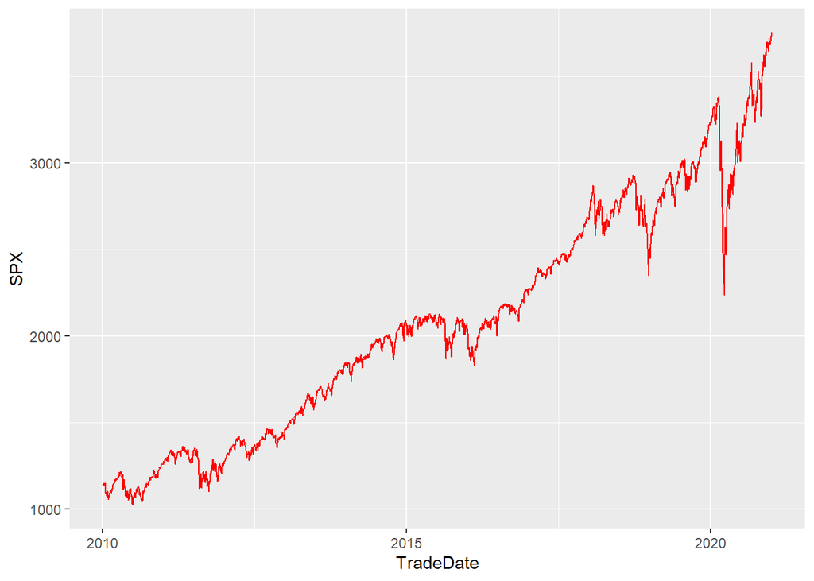

```r
selectedUnderlying %>%
  ggplot(aes(x=TradeDate,y=SPX))+
  geom_line(colour="red")
```

```r
mean(selectedUnderlying$logRetSPX)*252
```

```
## [1] 0.1091132
```

```r
var(selectedUnderlying$logRetSPX)
```

```
## [1] 0.0001223562
```

```r
sqrt(var(selectedUnderlying$logRetSPX)*252)
```

```
## [1] 0.1755955
```

```r
skewness(selectedUnderlying$logRetSPX)
```

```
## [1] -0.8640763
```

```r
kurtosis(selectedUnderlying$logRetSPX)
```

```
## [1] 19.34186
```

```r
# normality test
jarque.bera.test(selectedUnderlying$logRetSPX)
```

```
##
##  Jarque Bera Test
##
## data:  selectedUnderlying$logRetSPX
## X-squared = 31145, df = 2, p-value < 2.2e-16
```

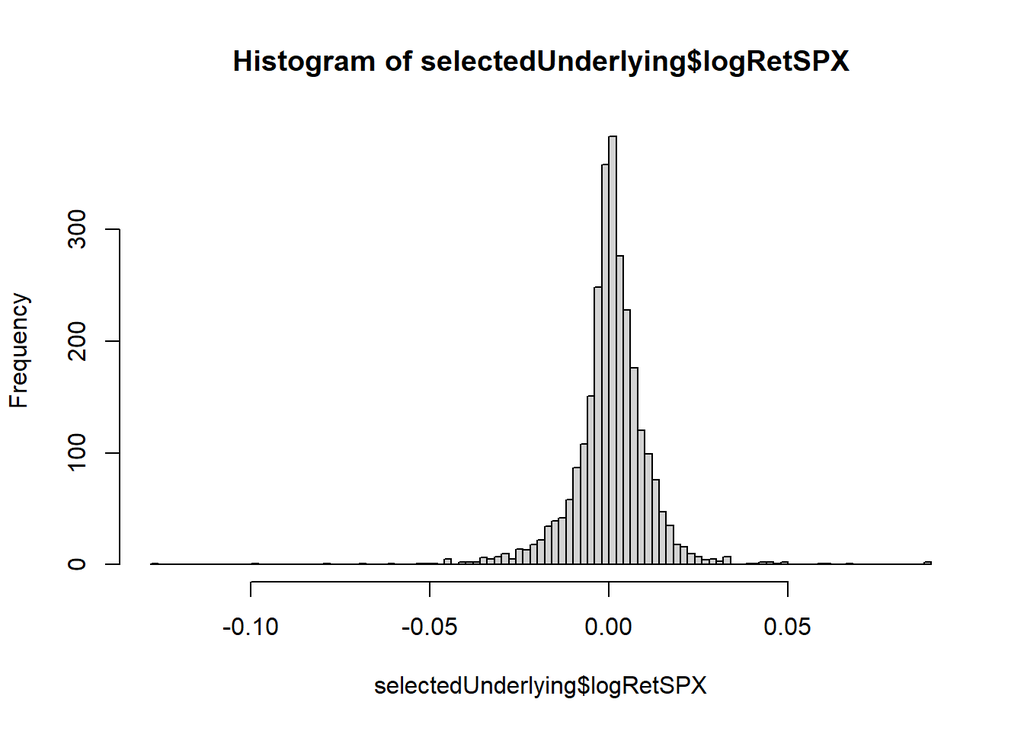

```r
hist(selectedUnderlying$logRetSPX, breaks = 100)
```

```r
d <- density(selectedUnderlying$logRetSPX)
d
```

```
##
## Call:
##  density.default(x = selectedUnderlying$logRetSPX)
##
## Data: selectedUnderlying$logRetSPX (2768 obs.);  Bandwidth 'bw' = 0.001218
##
##        x                  y
##  Min.   :-0.13131   Min.   : 0.00000
##  1st Qu.:-0.07515   1st Qu.: 0.00247
##  Median :-0.01898   Median : 0.11210
##  Mean   :-0.01898   Mean   : 4.44731
##  3rd Qu.: 0.03718   3rd Qu.: 1.25668
##  Max.   : 0.09334   Max.   :66.72459
```

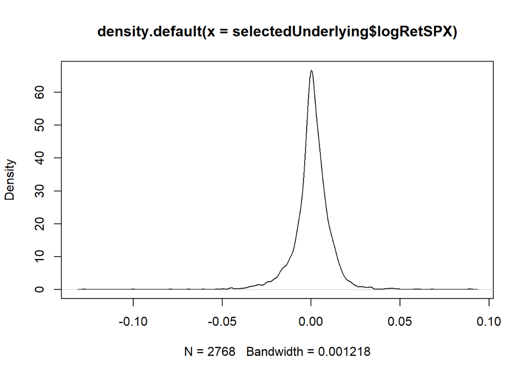

```r
plot(d)
```

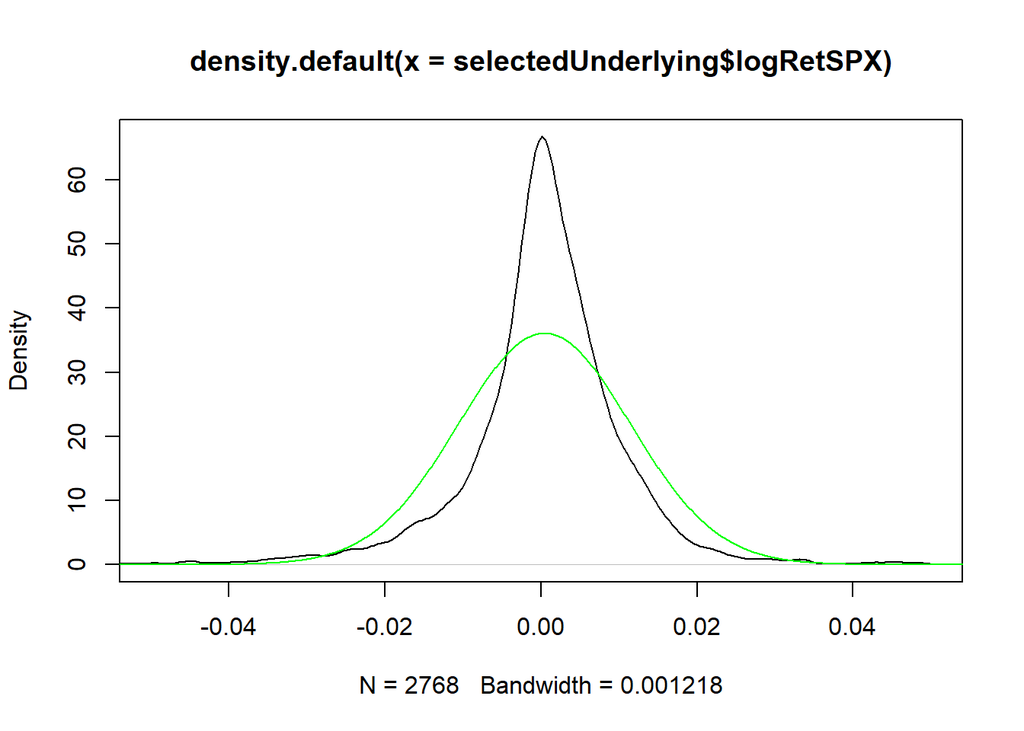

```r
# compare empirical density and a normal distribution with the same mean and variance

xAxis=seq(-0.15,0.1,by=0.0001)
plot(d,xlim = c(-0.05,0.05))
lines(xAxis,dnorm(xAxis, mean(selectedUnderlying$logRetSPX), sqrt(var(selectedUnderlying$logRetSPX))),col="green")
```

##### 1.1.2 Summary of SPY log return

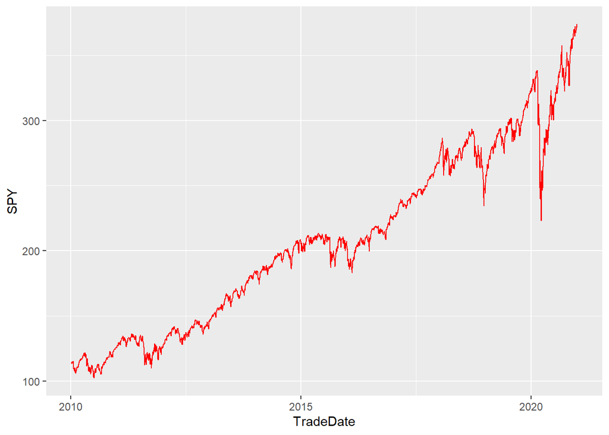

```r
selectedUnderlying %>%
  ggplot(aes(x=TradeDate,y=SPY))+
  geom_line(colour="red")
```

```r
mean(selectedUnderlying$logRetSPY)*252
```

```
## [1] 0.1086687
```

```r
var(selectedUnderlying$logRetSPY)
```

```
## [1] 0.0001198561
```

```r
sqrt(var(selectedUnderlying$logRetSPY)*252)
```

```
## [1] 0.1737922
```

```r
skewness(selectedUnderlying$logRetSPY)
```

```
## [1] -0.856228
```

```r
kurtosis(selectedUnderlying$logRetSPY)
```

```
## [1] 17.18241
```

```r
# normality test
jarque.bera.test(selectedUnderlying$logRetSPY)
```

```
##
##  Jarque Bera Test
##
## data:  selectedUnderlying$logRetSPY
## X-squared = 23536, df = 2, p-value < 2.2e-16
```

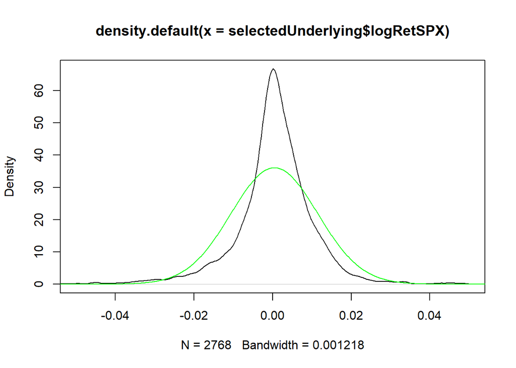

```r
# compare empirical density and a normal distribution with the same mean and variance

xAxis=seq(-0.15,0.1,by=0.0001)
plot(d,xlim = c(-0.05,0.05))
lines(xAxis,dnorm(xAxis, mean(selectedUnderlying$logRetSPX), sqrt(var(selectedUnderlying$logRetSPX))),col="green")
```

##### 1.1.3 Summary of SPX option (log return?)

```r
NspxOpt <- length(underlying$SPX)

underlying <- underlying %>%
  mutate(retSPX=c(NA,SPX[2:NspxOpt]/SPX[1:NspxOpt-1]-1),
         logRetSPX=c(NA,diff(log(SPX)))
         ) %>%
  na.omit()
```

#### *1.2 Present and comment on the relationship between S&P 500 index and SDPR ETF. (5%)*

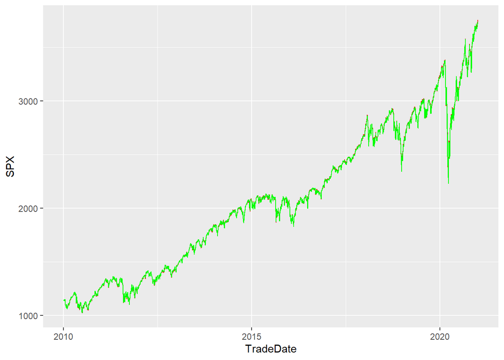

```r
selectedUnderlying %>%
  ggplot()+
  geom_line(aes(x=TradeDate,y=SPX),colour="red")+
  geom_line(aes(x=TradeDate,y=SPY*10),colour="green")
```

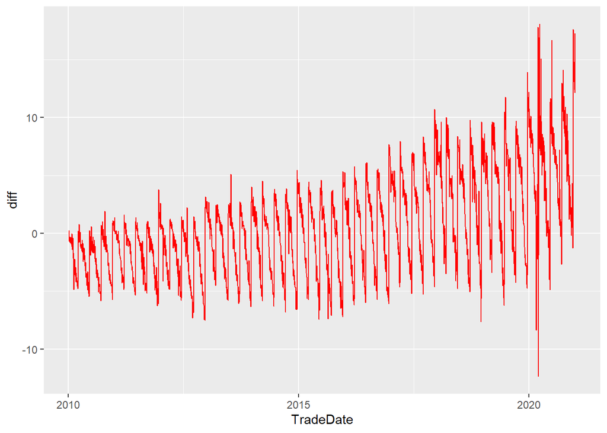

```r
#according to above plot, spx is quiet close to spy*10.  try plot out the diff and %diff
selectedUnderlying <- selectedUnderlying %>%
  mutate(diff=SPX-SPY*10)

selectedUnderlying %>%
  ggplot(aes(x=TradeDate,y=diff))+
  geom_line(colour="red")
```

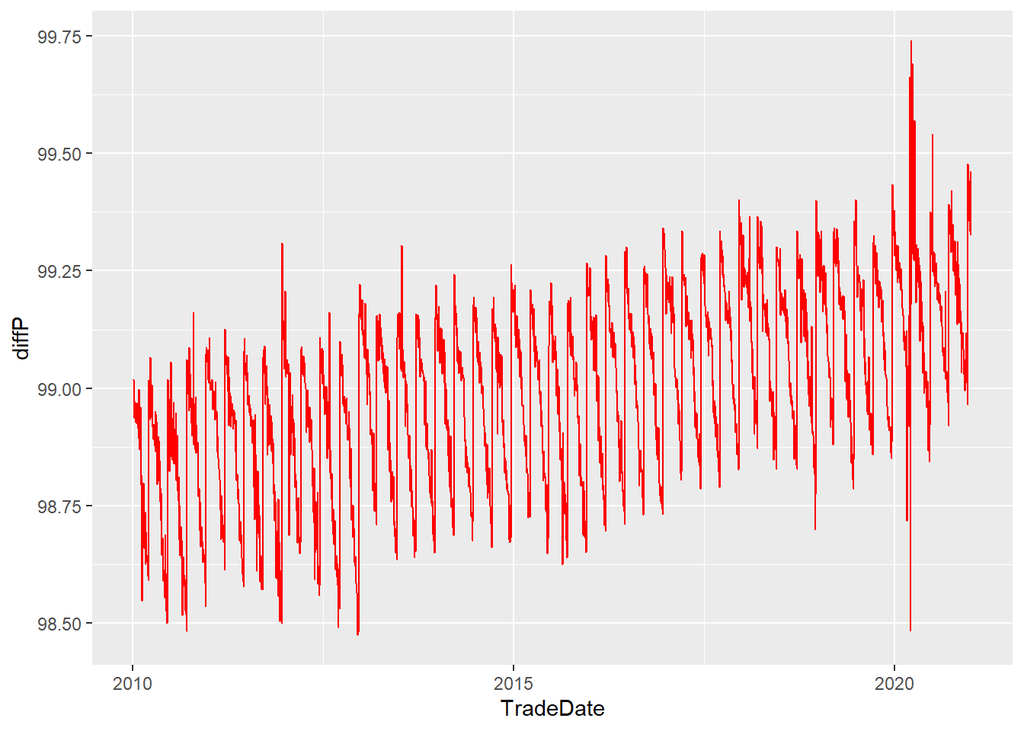

```r
selectedUnderlying <-
  selectedUnderlying %>%
  mutate(diffP=(SPX/SPY*10)-1)

selectedUnderlying %>%
  ggplot(aes(x=TradeDate,y=diffP))+
  geom_line(colour="red")
```

#### *1.3 Use time series of S&P 500 futures prices, present and comment the relationship between S&P 500 futures and S&P 500 index level. (5%)*

```r
#merge SPX to TS by Date

spEminiTS=merge(x=spEminiTS,y=underlying[c('TradeDate','SPX')],by="TradeDate",all.x=TRUE)
```

```r
spEminiTS <-
  spEminiTS %>%
  mutate(Basis=spEminiTS$`19/06/2020`-SPX,
         BasisP=SPX/spEminiTS$`19/06/2020`-1)
```

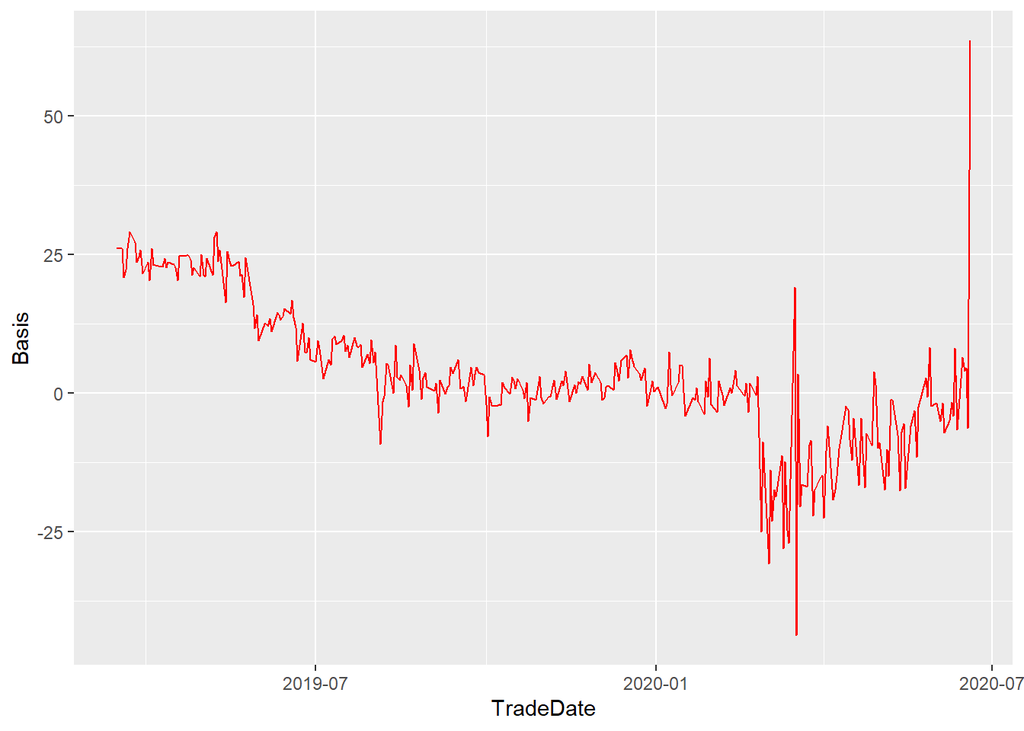

```r
spEminiTS %>%
  ggplot(aes(x=TradeDate,y=Basis))+
  geom_line(colour="red")
```

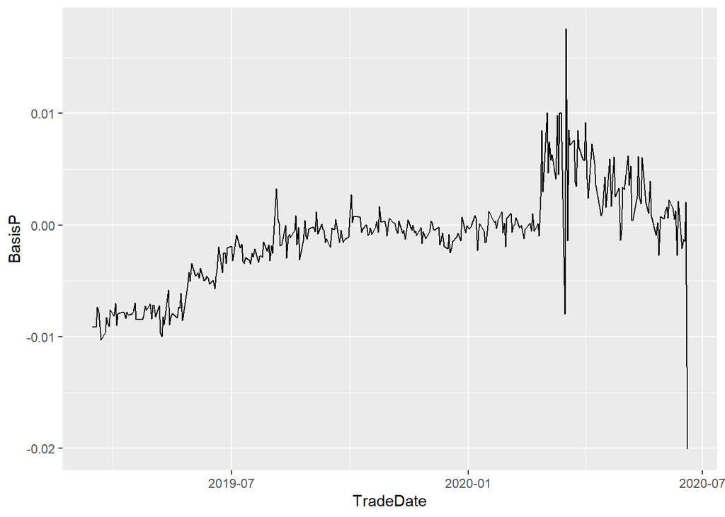

```r
spEminiTS %>%
  ggplot(aes(x=TradeDate,y=BasisP))+
  geom_line()
```

#### *2.1 Estimate the put-call parity implied underlying asset price. Compare the put-call parity implied underlying asset price with the S&P 500 index level and S&P 500 futures price. Calculate put-call parity implied interest rate and dividend yield. Does put-call parity implied underlying asset price always move in the same direction as the S&P 500 index level? (15%)*

```r
#spxOptionCross %<>%   arrange(expiryDate)

sort(unique(spxOptionCross$expiryDate))
```

```
##  [1] "2020-01-17" "2020-02-21" "2020-03-20" "2020-04-17" "2020-05-15"
##  [6] "2020-06-19" "2020-09-18" "2020-10-16" "2020-11-20" "2020-12-18"
## [11] "2021-01-15" "2021-03-19" "2021-06-18" "2021-12-17" "2022-12-16"
```

```r
selectedExpiry <- "2020-06-19"#select from sort?

oneExpiryOptionData <-
  spxOptionCross %>%
  filter(expiryDate==selectedExpiry)
```

###### calculate business days

```r
business_calendar <-
  create.calendar('my_calendar',
                  weekdays = c('saturday','sunday'))

ttm=bizdays(oneExpiryOptionData$TradeDate[1],
            oneExpiryOptionData$expiryDate[1],
            cal = business_calendar)/252
```

```r
#Call Option
callOptionData <- filter(oneExpiryOptionData,c_p==1)

callOptionData <- callOptionData %>%
  arrange(strike)

#Put Option
putOptionData <- filter(oneExpiryOptionData,c_p==0)

putOptionData <- putOptionData %>%
  arrange(strike)
```

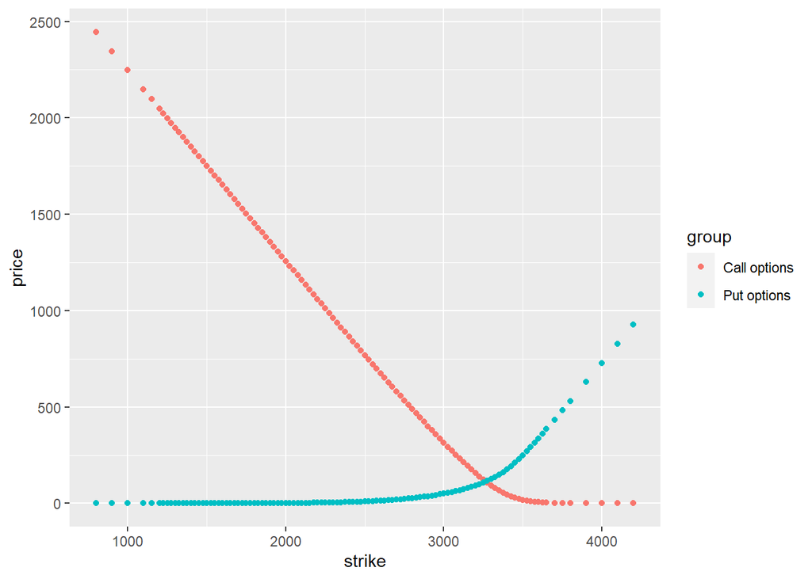

```r
group <- ifelse(oneExpiryOptionData$c_p==1, "Call options", "Put options")

oneExpiryOptionData %>%
  ggplot(aes(x=strike,y=price,color=group))+
  geom_point()
```

###### pair call and put

```r
pairedOptions <-
  oneExpiryOptionData %>%
  distinct(strike) %>%
  arrange(strike) %>%
  data.frame() %>%
  left_join(callOptionData[,c('strike','price')],by="strike")# merge by strike
```

```r
pairedOptions <-
  pairedOptions %>%
  rename(callPrice=price) %>%
  left_join(putOptionData[,c('strike','price')],by="strike") %>%
  rename(putPrice=price)
```

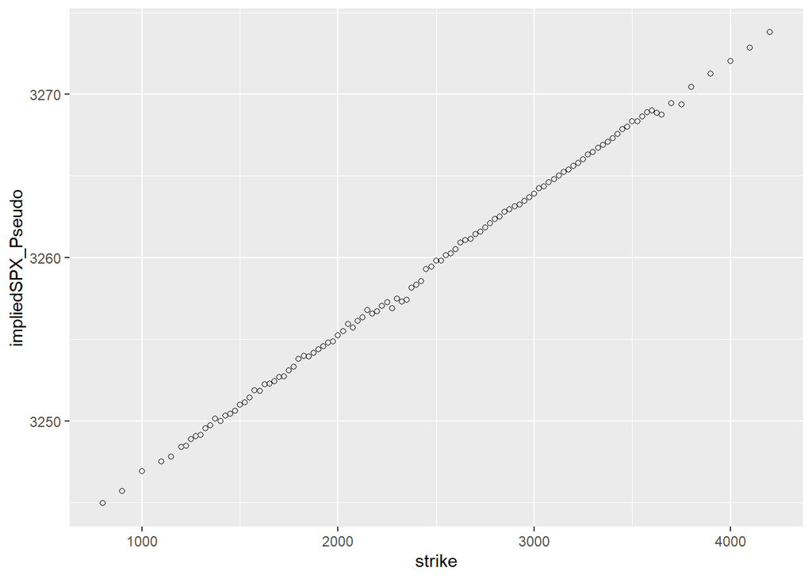

```r
pairedOptions %<>%
  mutate(impliedSPX_Pseudo=callPrice+strike-putPrice)
#plot
ggplot(pairedOptions,aes(x=strike,y=impliedSPX_Pseudo))+
  geom_point(shape = 1)
```

###### implied futures, interest rate

```r
sampleImpliedR <-
  pairedOptions %>%
  mutate(x=putPrice-callPrice) %>%
  select(strike,x) %>%
  data.frame()

#linear regression
resIR=lm(strike ~ x, data = sampleImpliedR)

impliedSPXF=resIR$coefficients[1]

impliedR=log(resIR$coefficients[2])/ttm
```

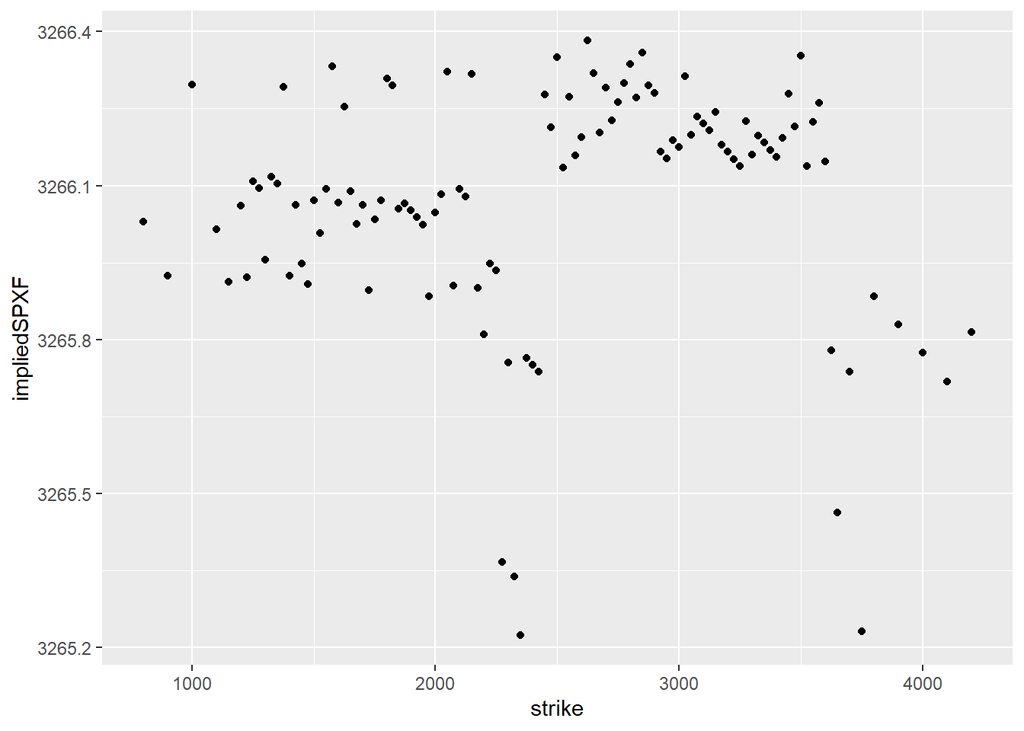

```r
pairedOptions <- pairedOptions %>%
  mutate(impliedSPXF=(callPrice-putPrice)*exp(impliedR*ttm)+strike)
#
ggplot(pairedOptions,aes(x=strike,y=impliedSPXF))+
  geom_point()
```

###### get the corresponding index level

```r
underlying <- read.csv("./sampleData/underlyingSampleData.csv", header=T,as.is = T)

underlying$TradeDate %<>%
  as.Date("%Y-%m-%d")

spotUnderlying <- underlying[underlying$TradeDate=="2020-01-10",'SPX']
```

###### get the corresponding futures price

```r
spEminiCross <- read.csv("./sampleData/spxEminiTrade20200110.csv", header=T,as.is = T,check.names=FALSE)

spEminiCross$TradeDate %<>% as.Date("%d/%m/%Y")

spotSPEmini <- spEminiCross[1,'19/06/2020']
```

###### implied dividend yield

```r
impliedDividend <- impliedR-log(impliedSPXF/spotUnderlying)/ttm
```

###### implied index level

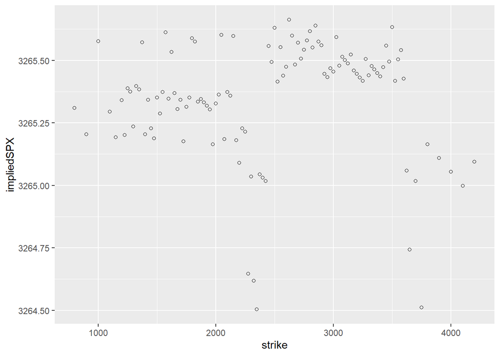

```r
pairedOptions <-
  pairedOptions %>%
  mutate(impliedSPX=
           (callPrice-putPrice+strike*exp(-impliedR*ttm))
         *exp(impliedDividend*ttm)
         )
#Plot
ggplot(pairedOptions,aes(x=strike,y=impliedSPX))+
  geom_point(shape=1)
```

```r
impliedSPX <- mean(pairedOptions$impliedSPX)
```

#### *2.2 Compare option price bounds and the market option prices. Does option prices within the theoretical bounds? Is there an arbitrage opportunity? (5%)*

##### call options

```r
callOptionData <-
  callOptionData %>%
  mutate(upperBound=spotUnderlying,
         lowerBound=impliedSPX*exp(-impliedDividend*ttm)-strike*exp(-impliedR*ttm))

callOptionData$lowerBound[callOptionData$lowerBound<0]=0
```

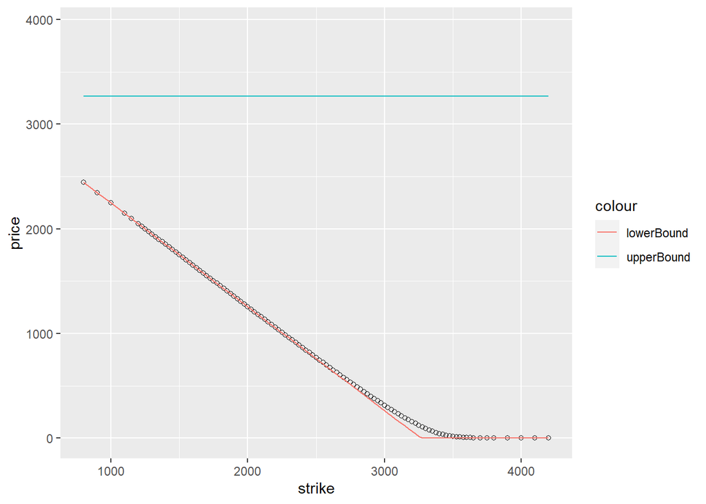

```r
callOptionData %>%
  ggplot(aes(x=strike))+
  ylim(0,spotUnderlying*1.2)+
  geom_point(aes(y=price),shape=1)+
  geom_line(aes(y=upperBound,colour="upperBound"))+
  geom_line(aes(y=lowerBound,colour="lowerBound"))
```

##### put option

```r
putOptionData <-
  putOptionData %>%
  mutate(upperBound=strike*exp(-impliedR*ttm),
         lowerBound=strike*exp(-impliedR*ttm)-spotUnderlying*exp(-impliedDividend*ttm))

putOptionData$lowerBound[putOptionData$lowerBound<0]=0
```

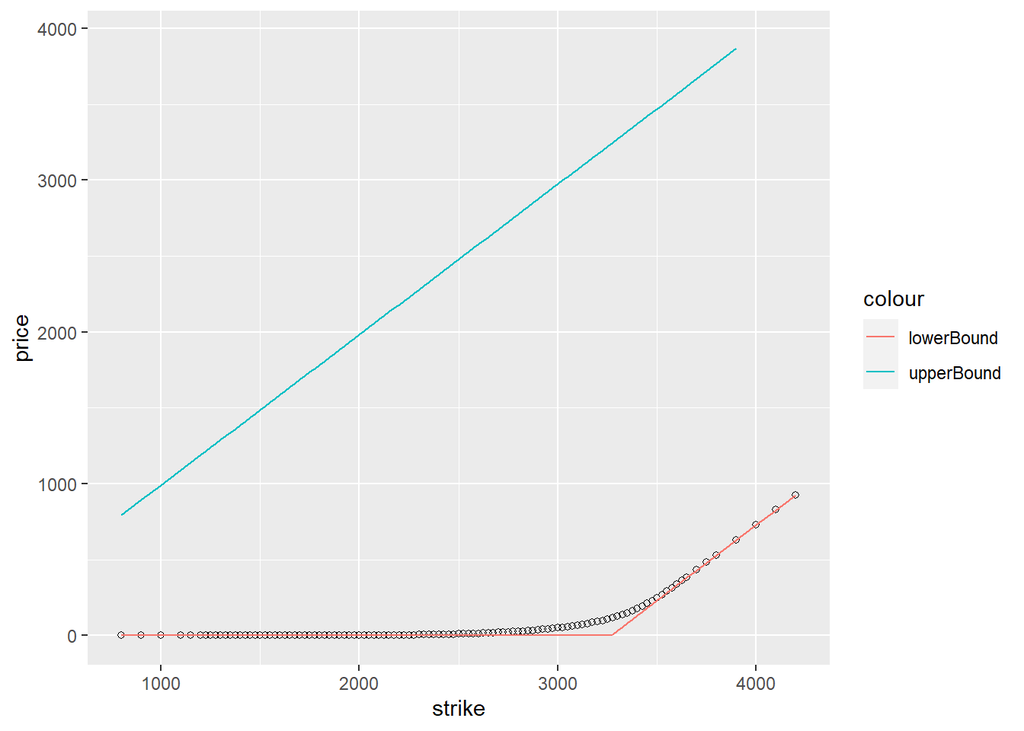

```r
putOptionData %>%
  ggplot(aes(x=strike))+
  ylim(0,spotUnderlying*1.2)+
  geom_point(aes(y=price),shape=1)+
  geom_line(aes(y=upperBound,colour="upperBound"))+
  geom_line(aes(y=lowerBound,colour="lowerBound"))
```

##### 3.1.1 Stock with continuous dividend yield

```r
nSteps=2
interestRate=0.05
dividendYield=0.02
volatility=0.2
ttm=6/12
spotUndelrying=810
strike=800
call_put=1 #1 for call option, -1 for put option

americanOption=FALSE
displayBT=TRUE

deltaT=ttm/nSteps

uCRR=exp(volatility*sqrt(deltaT))

dCRR=exp(-volatility*sqrt(deltaT))

aCRR=exp((interestRate-dividendYield)*(deltaT))

pCRR=(aCRR-dCRR)/(uCRR-dCRR)
```

###### state price at expiry

```r
statesTemp=rep(NA,nSteps+1)
for (j in 1:(nSteps+1)){
  statesTemp[j]=spotUndelrying*uCRR^(j-1)*dCRR^(nSteps-(j-1))
}
print(statesTemp)
```

```
## [1] 663.1719 810.0000 989.3362
```

###### option price at expiry

```r
# note: nSetps=2
optionTemp=rep(NA,nSteps+1)
for (j in 1:(nSteps+1)){
  optionTemp[j]=max((statesTemp[j]-strike)*call_put,0)
}
cat("state price at step ",nSteps+1," is: ",statesTemp,'\n')
```

```
## state price at step  3  is:  663.1719 810 989.3362
```

```r
cat("Option price at step ",nSteps+1," is: ",optionTemp,'\n')
```

```
## Option price at step  3  is:  0 10 189.3362
```

###### state price and option price at each node

```r
for (i in nSteps:1){
  optionTemp_1=rep(NA,i)
  statesTemp=rep(NA,i)
  for (j in 1:i){
    statesTemp[j]=spotUndelrying*uCRR^(j-1)*dCRR^(i-1-(j-1))
  }

  if (americanOption==TRUE){
    for (j in 1:i){
      optionTemp_1[j]=max(((1-pCRR)*optionTemp[j]+pCRR*optionTemp[j+1])*exp(-interestRate*deltaT),(statesTemp[j]-strike)*call_put)
    }
  }  else{
    for (j in 1:i){
      optionTemp_1[j]=((1-pCRR)*optionTemp[j]+pCRR*optionTemp[j+1])*exp(-interestRate*deltaT)
    }
  }

  optionTemp=optionTemp_1
  if (displayBT==TRUE){
    cat("state price at step ",i," is: ",statesTemp,'\n')
    cat("Option price at step ",i," is: ",optionTemp,'\n')
  }
}
```

```
## state price at step  2  is:  732.9183 895.1884
## Option price at step  2  is:  5.062315 100.6614
## state price at step  1  is:  810
## Option price at step  1  is:  53.39472
```

```r
cat("Option price is: ",optionTemp)
```

```
## Option price is:  53.39472
```

##### 3.1.2 stock with continuous dividend yield 1000 steps

```r
nSteps=1000
interestRate=0.05
dividendYield=0.02
volatility=0.2
ttm=6/12
spotUndelrying=810
strike=800
call_put=1 #1 for call option, -1 for put option

americanOption=FALSE

displayBT=FALSE

deltaT=ttm/nSteps

uCRR=exp(volatility*sqrt(deltaT))

dCRR=exp(-volatility*sqrt(deltaT))

aCRR=exp((interestRate-dividendYield)*(deltaT))

pCRR=(aCRR-dCRR)/(uCRR-dCRR)
```

###### state price at expiry

```r
statesTemp=rep(NA,nSteps+1)
for (j in 1:(nSteps+1)){
  statesTemp[j]=spotUndelrying*uCRR^(j-1)*dCRR^(nSteps-(j-1))
}
print(statesTemp)
```

[output not shown]

[output cut: 186 more lines]

###### option price at expiry

```r
optionTemp=rep(NA,nSteps+1)
for (j in 1:(nSteps+1)){
  optionTemp[j]=max((statesTemp[j]-strike)*call_put,0)
}
cat("state price at step ",nSteps+1," is: ",statesTemp,'\n')
```

```
## state price at step  1001  is:  9.252542 9.33567 9.419545 9.504174 9.589564 9.67572 9.76265 9.850362 9.938861 10.02816 10.11825 10.20916 10.30088 10.39343 10.48681 10.58103 10.67609 10.77201 10.86879 10.96644 11.06496 11.16438 11.26468 11.36589 11.468 11.57104 11.67499 11.77989 11.88572 11.99251 …
```

```r
cat("Option price at step ",nSteps+1," is: ",optionTemp,'\n')
```

```
## Option price at step  1001  is:  0 0 0 0 0 0 0 0 0 0 0 0 0 0 0 0 0 0 0 0 0 0 0 0 0 0 0 0 0 0 0 0 0 0 0 0 0 0 0 0 0 0 0 0 0 0 0 0 0 0 0 0 0 0 0 0 0 0 0 0 0 0 0 0 0 0 0 0 0 0 0 0 0 0 0 0 0 0 0 0 0 0 0 0 0 0 0 0 0 0 0 0 0 0 0 0 0 0 0 0 0 0 0 0 0 0 0 0 0 0 0 0 0 0 0 0 0 0 0 0 0 0 0 0 0 0 0 0 0 0 0 0 …
```

###### state price and option price at each node

```r
for (i in nSteps:1){
  optionTemp_1=rep(NA,i)
  statesTemp=rep(NA,i)
  for (j in 1:i){
    statesTemp[j]=spotUndelrying*uCRR^(j-1)*dCRR^(i-1-(j-1))
  }

  if (americanOption==TRUE){
    for (j in 1:i){
      optionTemp_1[j]=max(((1-pCRR)*optionTemp[j]+pCRR*optionTemp[j+1])*exp(-interestRate*deltaT),(statesTemp[j]-strike)*call_put)
    }
  }  else{
    for (j in 1:i){
      optionTemp_1[j]=((1-pCRR)*optionTemp[j]+pCRR*optionTemp[j+1])*exp(-interestRate*deltaT)
    }
  }

  optionTemp=optionTemp_1
  if (displayBT==TRUE){
    cat("state price at step ",i," is: ",statesTemp,'\n')
    cat("Option price at step ",i," is: ",optionTemp,'\n')
  }

}

cat("Option price is: ",optionTemp)
```

```
## Option price is:  56.2858
```

##### 3.1.3 futures

```r
nSteps=3
interestRate=0.05
dividendYield=0.05
volatility=0.3
ttm=9/12
spotUndelrying=31
strike=30
call_put=-1 #1 for call option, -1 for put option

americanOption=TRUE

displayBT=TRUE

deltaT=ttm/nSteps

uCRR=exp(volatility*sqrt(deltaT))

dCRR=exp(-volatility*sqrt(deltaT))

aCRR=exp((interestRate-dividendYield)*(deltaT))

pCRR=(aCRR-dCRR)/(uCRR-dCRR)
```

###### state price at expiry

```r
statesTemp=rep(NA,nSteps+1)
for (j in 1:(nSteps+1)){
  statesTemp[j]=spotUndelrying*uCRR^(j-1)*dCRR^(nSteps-(j-1))
}
print(statesTemp)
```

```
## [1] 19.76647 26.68195 36.01686 48.61768
```

###### option price at expiry

```r
optionTemp=rep(NA,nSteps+1)
for (j in 1:(nSteps+1)){
  optionTemp[j]=max((statesTemp[j]-strike)*call_put,0)
}
cat("state price at step ",nSteps+1," is: ",statesTemp,'\n')
```

```
## state price at step  4  is:  19.76647 26.68195 36.01686 48.61768
```

```r
cat("Option price at step ",nSteps+1," is: ",optionTemp,'\n')
```

```
## Option price at step  4  is:  10.23353 3.318053 0 0
```

###### state price and option price at each node

```r
for (i in nSteps:1){
  optionTemp_1=rep(NA,i)
  statesTemp=rep(NA,i)
  for (j in 1:i){
    statesTemp[j]=spotUndelrying*uCRR^(j-1)*dCRR^(i-1-(j-1))
  }

  if (americanOption==TRUE){
    for (j in 1:i){
      optionTemp_1[j]=max(((1-pCRR)*optionTemp[j]+pCRR*optionTemp[j+1])*exp(-interestRate*deltaT),(statesTemp[j]-strike)*call_put)
    }
  }  else{
    for (j in 1:i){
      optionTemp_1[j]=((1-pCRR)*optionTemp[j]+pCRR*optionTemp[j+1])*exp(-interestRate*deltaT)
    }
  }

  optionTemp=optionTemp_1
  if (displayBT==TRUE){
    cat("state price at step ",i," is: ",statesTemp,'\n')
    cat("Option price at step ",i," is: ",optionTemp,'\n')
  }
}
```

```
## state price at step  3  is:  22.96536 31 41.84562
## Option price at step  3  is:  7.034635 1.761069 0
## state price at step  2  is:  26.68195 36.01686
## Option price at step  2  is:  4.538158 0.9346941
## state price at step  1  is:  31
## Option price at step  1  is:  2.835635
```

```r
cat("Option price is: ",optionTemp)
```

```
## Option price is:  2.835635
```

##### 3.1.4 historical volatility

###### SPX (data pre loaded, ret pre caled,see 1.1)

[figure not shown]

```r
underlying$var=NA

m_days=60

# fill var
for (i in ((m_days+1):Nspx)){
  underlying[i,'var']=1/(m_days-1)*sum((
      underlying[(i-m_days-1):(i-1),'retSPX']-mean(underlying[(i-m_days-1):(i-1),'retSPX'])
      )^2)
}

#mutate std Annual
underlying <-
  underlying %>%
  mutate(stdAnnualSPX=(var*252/m_days)^0.5)

#plot
underlying[seq(from = 1, to = Nspx, by = m_days),] %>%
  ggplot(aes(x=TradeDate,y=stdAnnualSPX))+
  geom_line()
```

###### SPX volatility for binomial tree

```r
selectedTradeDate="2020-01-10"

spotUndelryingSPX=underlying[underlying$TradeDate==selectedTradeDate,'SPX']
volatilitySPX=underlying[underlying$TradeDate==selectedTradeDate,'stdAnnualSPX']

spotUndelrying2 <-
  underlying %>%
  filter(TradeDate==selectedTradeDate) %>%
  select(SPX,TradeDate)

volatilitySPX2 <-
  underlying %>%
  filter(TradeDate==selectedTradeDate) %>%
  select(stdAnnualSPX,TradeDate)
```

###### SPY (data pre loaded, ret pre caled,see 1.1)

[figure not shown]

```r
underlying$var=NA

m_days=60

# fill var
for (i in ((m_days+1):Nspx)){
  underlying[i,'var']=1/(m_days-1)*sum((
      underlying[(i-m_days-1):(i-1),'retSPY']-mean(underlying[(i-m_days-1):(i-1),'retSPY'])
      )^2)
}

#mutate std Annual
underlying <-
  underlying %>%
  mutate(stdAnnualSPY=(var*252/m_days)^0.5)

#plot
underlying[seq(from = 1, to = Nspx, by = m_days),] %>%
  ggplot(aes(x=TradeDate,y=stdAnnualSPY))+
  geom_line()
```

###### SPY volatility for binomial tree

```r
selectedTradeDate="2020-01-10"

spotUndelryingSPY=underlying[underlying$TradeDate==selectedTradeDate,'SPY']
volatilitySPY=underlying[underlying$TradeDate==selectedTradeDate,'stdAnnualSPY']

spotUndelryingSPY2 <-
  underlying %>%
  filter(TradeDate==selectedTradeDate) %>%
  select(SPY,TradeDate)

volatilitySPY2 <-
  underlying %>%
  filter(TradeDate==selectedTradeDate) %>%
  select(stdAnnualSPY,TradeDate)
```

# 需要参数对照进行一个二叉树的跑，以及跑多少次这个问题不确定

#### Dataset Explanation

> *Underlying* = S&P500 + SDPR ETF (SPY column) trade from 2010-01-04 to 2020-12-31

> *SPX option* trade at 2020-01-10 expiry from 2020-01-17 to 2022-12-16

> *And expiry* at 2020-06-19 trade from 2018-06-20 to 2020-06-18

> *SPY option* trade at 2020-01-10 expiry from 2020-01-10 to 2022-12-16

> *And expiry* at 2020-06-19 trade from 2018-06-22 to 2020-06-19

> *SPX mini futures* trade at 2020-01-10

> *And expiry* at 2020-06-19 trade from 2019-03-15to 2020-06-19